# Visualizing Genomic Data with IGV

The Integrative Genomics Viewer, hands-on

Graeme Grimes

## Today’s plan

1. Introduction to IGV
2. IGV basics
3. Loading your own genome
4. Alignments & SNPs
5. Precomputing coverage
6. RNA-seq & splicing
7. Variants & genotypes
8. Structural variants
9. Long reads optional
10. Wrap up

Have IGV open alongside the slides — most of today is hands-on.

# What is IGV?

Episode 01

What is a genome browser, and when would I use one?

## A genome browser

Instead of scrolling through millions of lines of text, **scroll and zoom along a chromosome** and see data line up against the reference.

IGV (Broad Institute) is popular because it:

- runs **locally** — your data never leaves your machine
- reads **only the region you are viewing**, so big files load fast
- supports dozens of **file formats**
- stacks data as **tracks** for side-by-side comparison

## Why look at your data?

- **Spot problems early** — misaligned reads, coverage gaps, wrong reference
- **Real signal or artifact?** — a heterozygous SNP vs. strand bias or low base quality
- **Build confidence** before spending time on downstream analysis

IGV *visualizes* the output of your pipelines (alignment, variant calling, …) — it does not do the processing.

## What can IGV show?

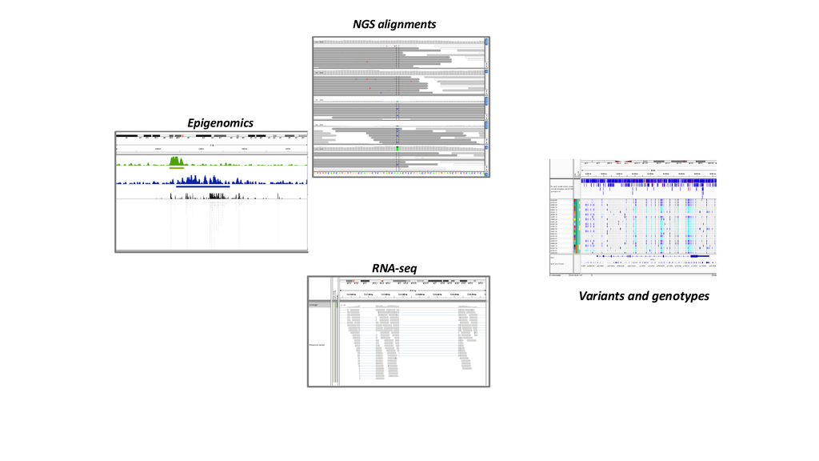

Epigenomic signal · NGS alignments · RNA-seq · Variants & genotypes — we’ll see all four today

## File formats we’ll use

| Format | Contains |
| --- | --- |
| **FASTA** (+ `.fai`) | Reference genome sequence |
| **BED** | Genomic intervals — genes, SNP calls |
| **BAM** (+ `.bai`) | Aligned sequencing reads |
| **TDF** | Precomputed coverage |
| **VCF** | Variant calls & sample genotypes |

Plus many more — BAM, CRAM, bigWig, GFF/GTF, …

## Your turn: launch IGV

Open IGV on your computer. You should see a genome drop-down (e.g. `Human hg19`) in the top left, a chromosome ideogram, and an empty track area.

If IGV doesn’t start, check you downloaded the right build for your OS — and put up your hand!

# IGV Basics

Episode 02

How do I load data and move around the genome?

## Load a genome and data

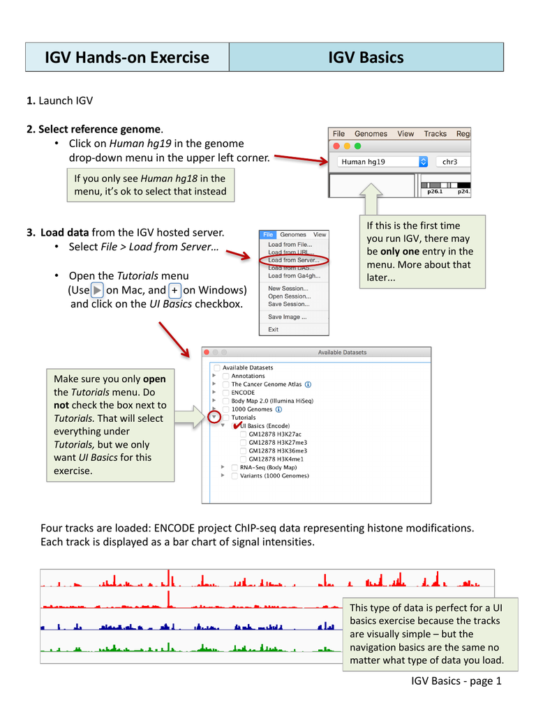

1. Genome drop-down → **Human hg19**
2. File > Load from Server…
3. Expand **Tutorials** → tick **UI Basics (Encode)**

Loads four ENCODE ChIP-seq tracks (histone modifications).

⚠️ Expand *Tutorials* — don’t tick the box next to it, or you’ll load everything!

## More hosted genomes

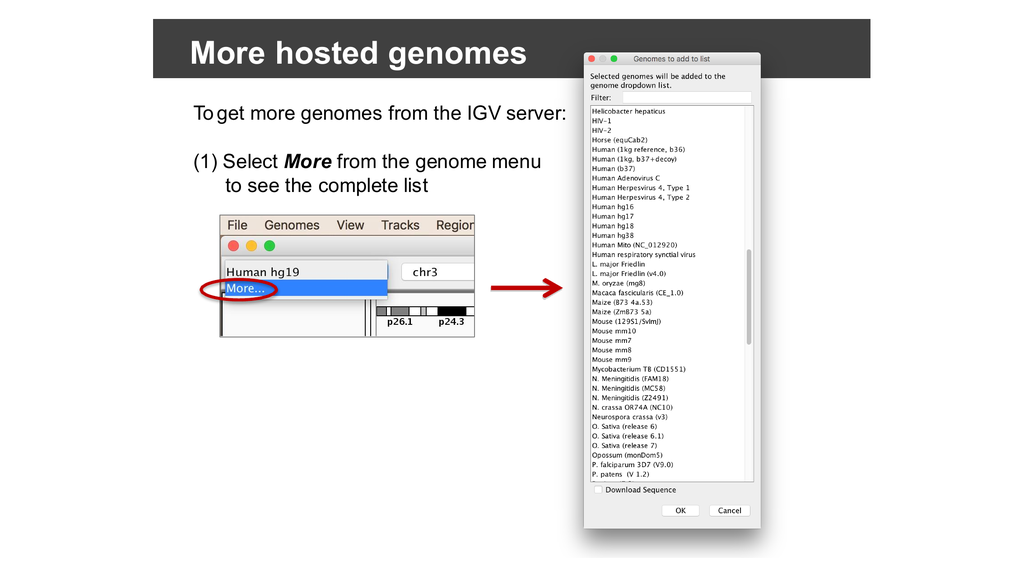

Genome drop-down → **More…** for bacteria, model organisms, other builds

## Four zoom levels

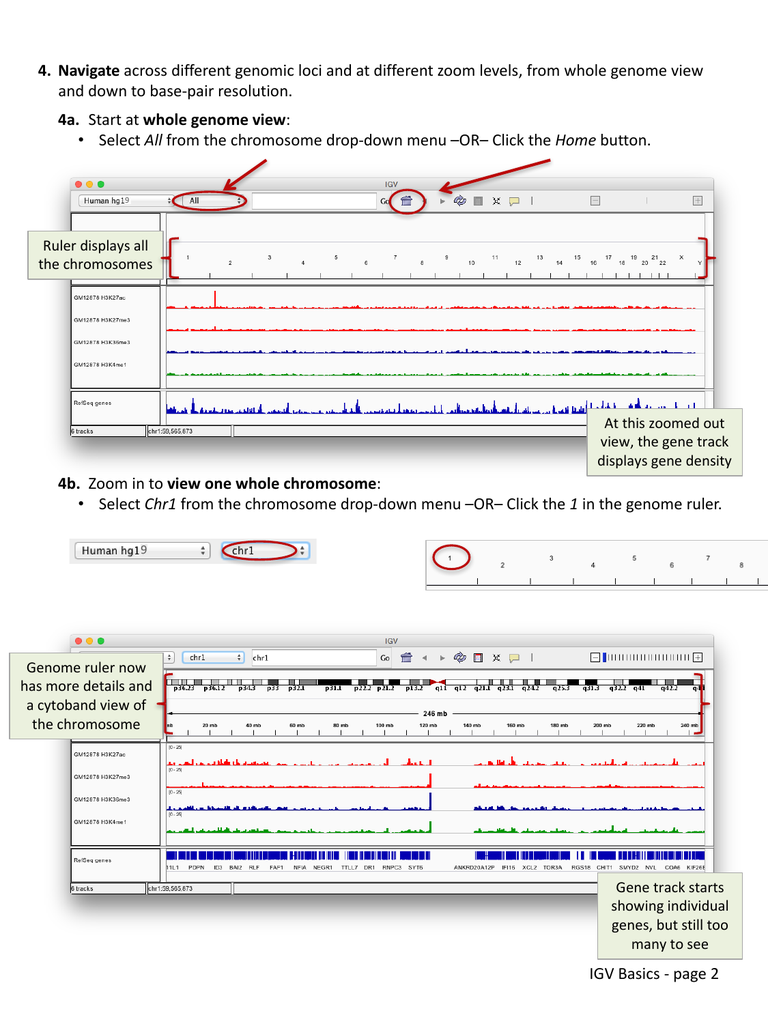

| Level | How |
| --- | --- |
| **Whole genome** | Chromosome menu → **All**, or *Home* |
| **Chromosome** | Pick **chr1**, or click **1** on the ruler |
| **Region** | Drag on the ruler; double-click a track |
| **Base pair** | Keep zooming, or use the zoom widget |

Alt-click zooms back out

## Getting around

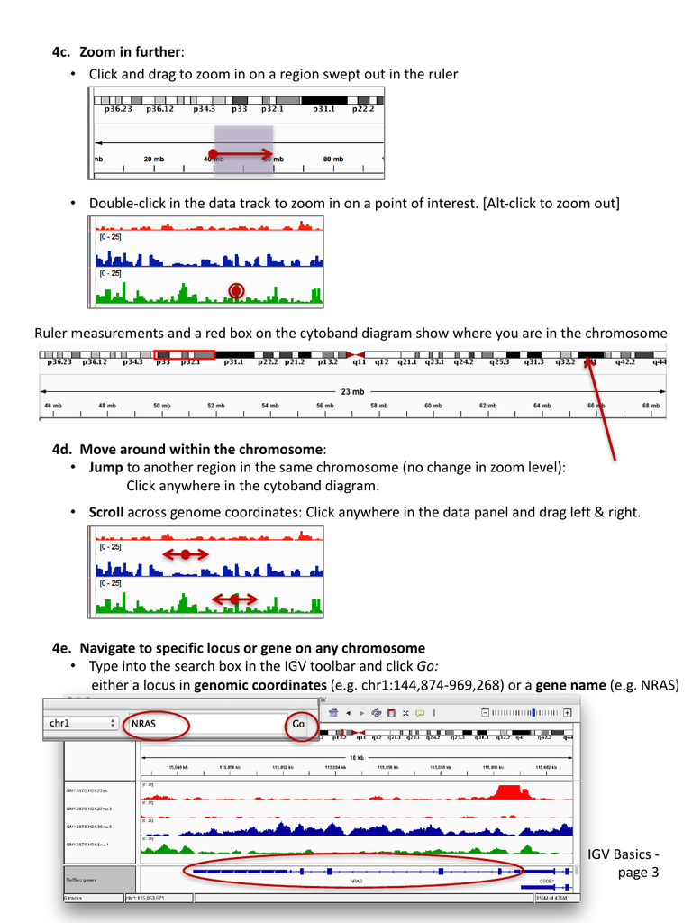

**Move without zooming**

- Click the **cytoband** to jump
- **Click and drag** in the data panel to scroll

**Jump straight there**

- Type a locus: `chr1:144,874,969-145,000,000`
- …or a gene name: `NRAS` → **Go**

## Your turn: find NRAS

Starting from the **whole-genome** view, go to **chr1**, then search for `NRAS`.

Keep zooming until you can read **individual bases**.

Search takes you to the whole gene. Drag on the ruler, double-click, or use **+** until letters appear in the sequence track.

## Sequence & gene tracks

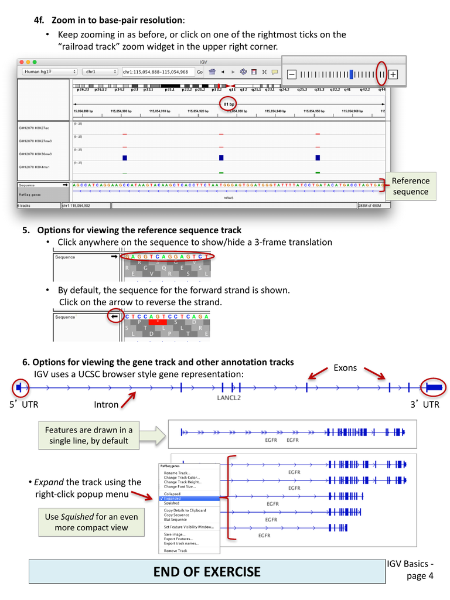

**Sequence track**

- One base per column once zoomed in
- Arrow → switch strand
- Click → 3-frame translation

**Gene track**

- Line = intron · thick block = exon · thinner end blocks = UTRs
- Right-click → **Collapsed / Expanded / Squished**

## Your turn: gene display modes

Go to `EGFR`. Right-click the *RefSeq genes* track and try **Collapsed**, **Expanded** and **Squished**.

What is the trade-off?

**Collapsed** — compact, can’t tell transcripts apart. **Expanded** — one transcript per row, easiest to read, uses the most space. **Squished** — one per row but thin: fits many, harder to read.

## Combining data tracks

Tools > Combine Data Tracks — add, subtract, multiply or divide two numeric tracks

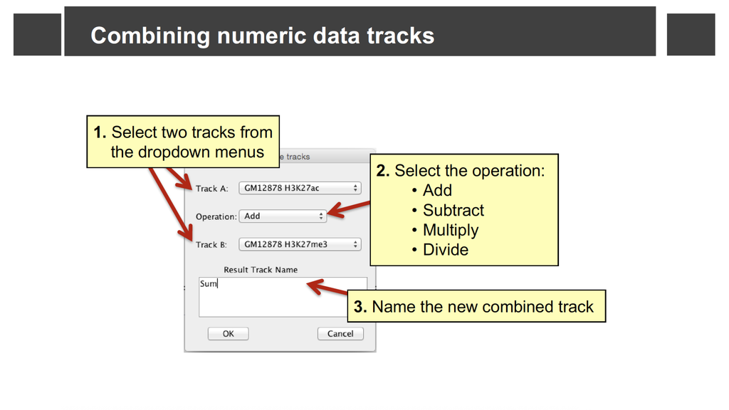

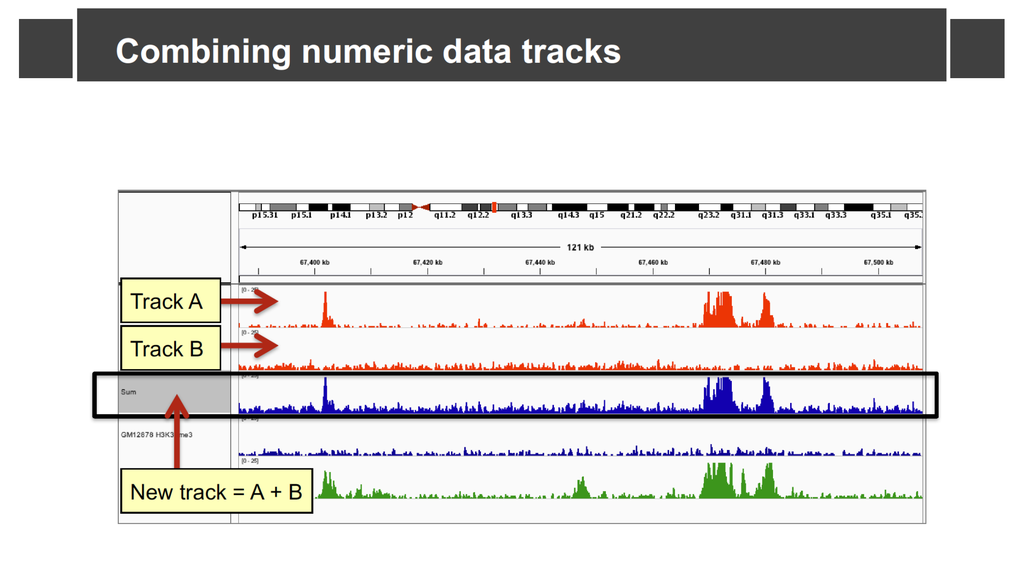

## Your turn: combine two tracks

Add two of the ENCODE ChIP-seq tracks together. How does the combined track compare to its two sources?

The **Sum** track peaks wherever *either* source peaks, with height equal to the total signal — one track to read instead of two.

## Watch: data navigation basics

[video not shown]

# Loading Your Own Genome

Episode 03

How do I view a genome that isn’t built into IGV?

## Genome from a FASTA file

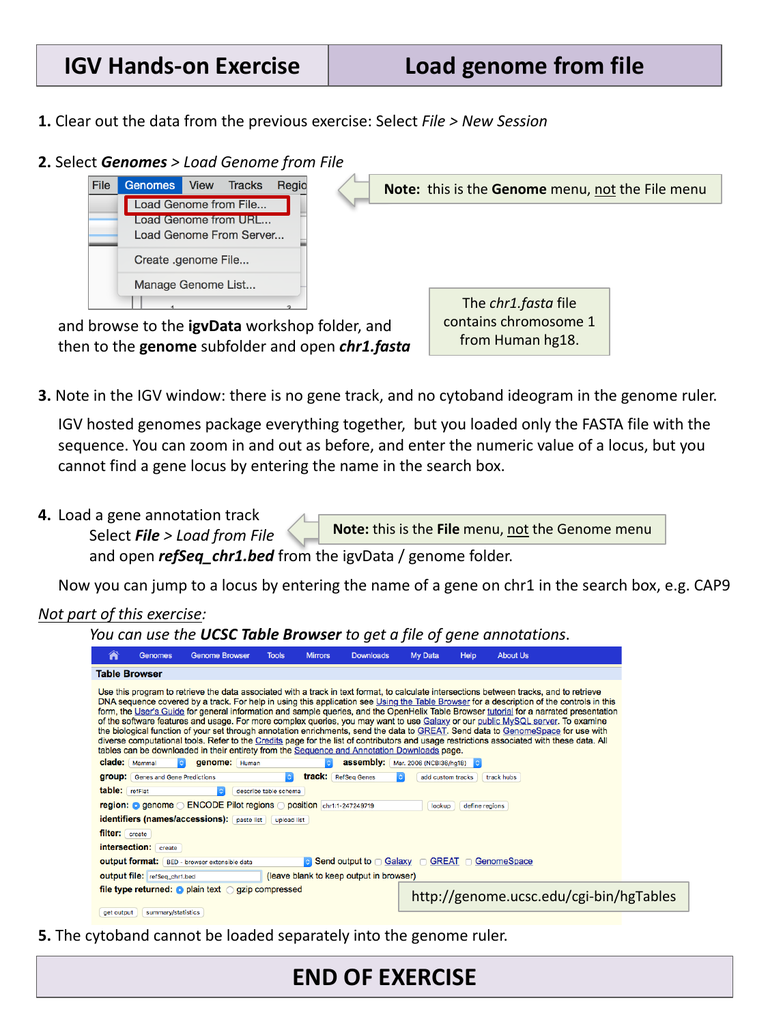

1. File > New Session to clear
2. Genomes > Load Genome from File…
3. Open `igvData/genome/chr1.fasta`

Now there’s **no gene track** and **no cytoband** — just sequence.

4. File > Load from File… → `refSeq_chr1.bed`

## Your turn: search by gene name

**Before** loading `refSeq_chr1.bed`, search for `CAP9`. What happens?

Now load the BED file and try again.

Without annotation IGV doesn’t know where genes are — only coordinates work. With the BED file loaded, the search jumps straight to the gene.

Annotation BED files like this can be downloaded from the UCSC Table Browser. Cytobands can’t be added separately.

# Alignments & SNPs

Episode 04

How can I tell a real SNP from an artifact?

## Paired-end reads

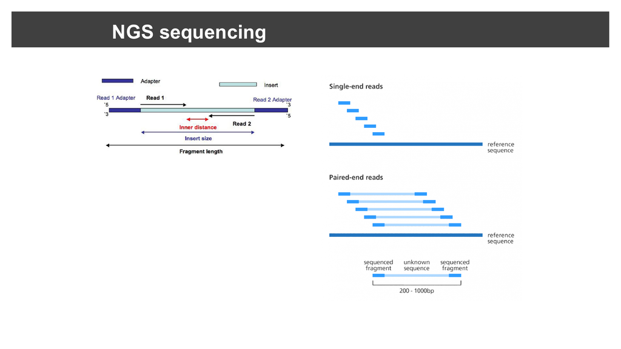

Each fragment is read from both ends · distance between outer edges = **insert size**

## The SAM / BAM format

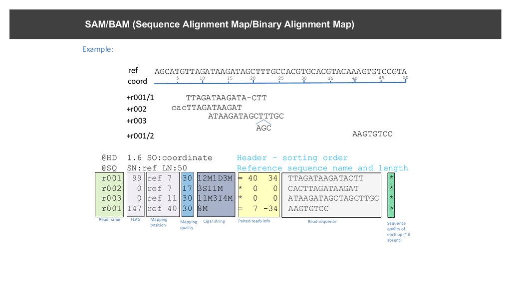

Read name · position · **mapping quality** · **CIGAR** · mate info · sequence & base qualities

## Load reads and SNP calls

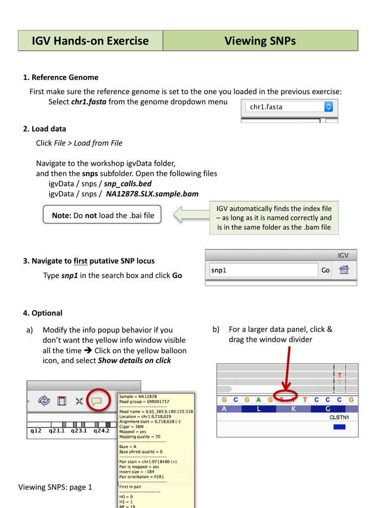

File > Load from File… in `igvData/snps/`:

- `snp_calls.bed` — two candidate SNPs
- `NA12878.SLX.sample.bam`

Search `snp1` → **Go**

Load only the `.bam` — IGV finds the `.bai` index automatically if it’s next to it.

## Sort by base

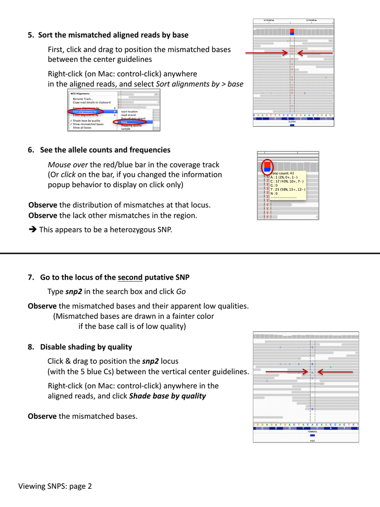

- Centre the mismatch between the guide lines
- Right-click → **Sort alignments by › base**
- Hover the **coverage bar** for allele counts

**A real het SNP looks like:** a consistent mismatch in ~50% of reads, and little noise around it.

## Your turn: compare snp1 & snp2

Go to `snp2`. Compare it with `snp1` — look at how **bright** the mismatched bases are.

Toggle **Shade base by quality** off and on.

At `snp2` many mismatches are faint → **low base quality**. With shading off they look just as convincing, which is misleading. First warning sign that `snp2` isn’t real.

## Sort & colour by strand

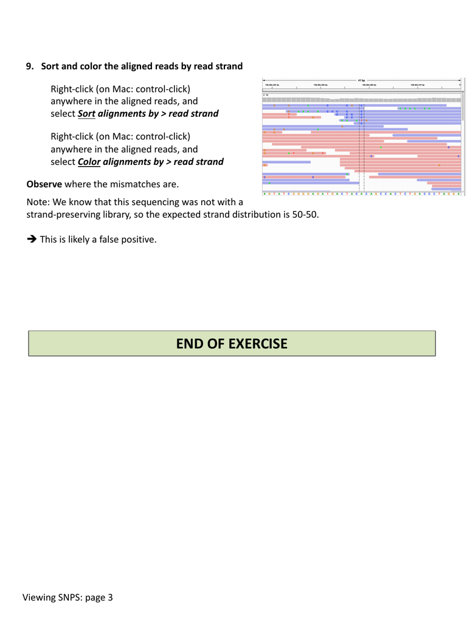

Right-click →

- **Sort alignments by › read strand**
- **Color alignments by › read strand**

Non-strand-specific library → expect a **50/50 split**.

A real variant appears on **both** strands. On one strand only = 🚩 artifact.

## Your turn: real or artifact?

Use strand sorting and colouring on `snp2`. The library was **not** strand-specific.

What do you conclude?

The mismatches sit on one strand only → likely a **false positive**. Together with the low base quality, that’s two independent pieces of evidence against it.

## BLAT: is the read really from here?

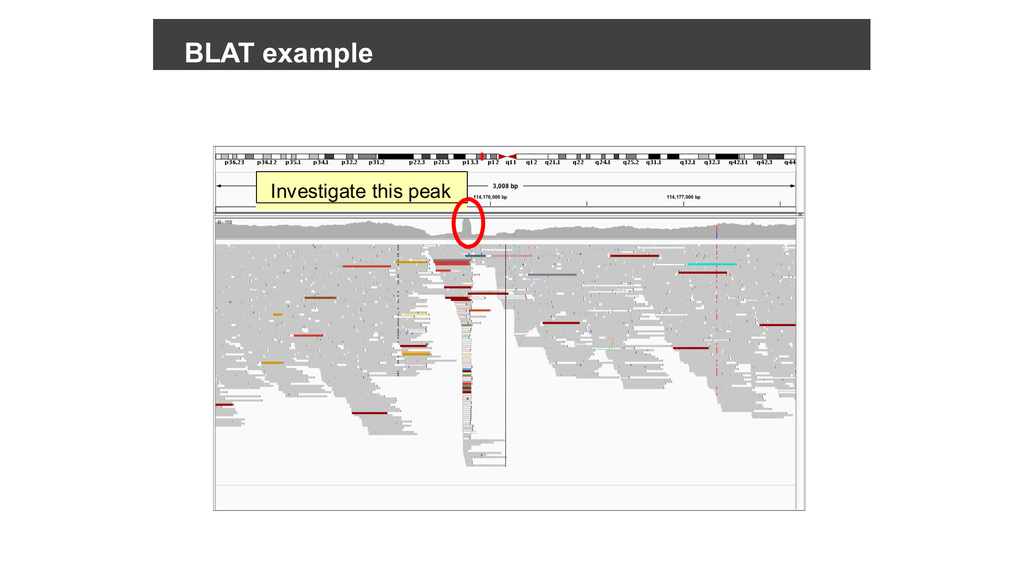

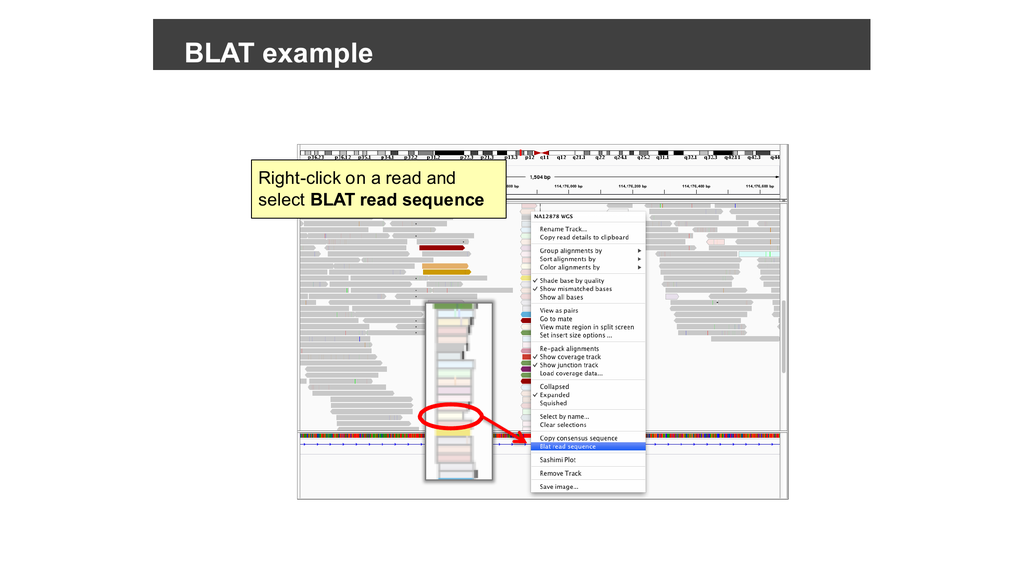

A suspiciously narrow coverage spike?

Right-click a read → **BLAT read sequence**

- One clear best hit → trustworthy
- Many hits with similar scores → **repetitive sequence**, treat with suspicion

## BLAT results

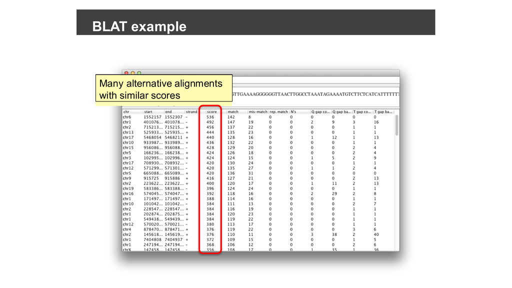

Many equally good hits across chromosomes → the read can’t be placed confidently

## Watch: sequencing data basics

[video not shown]

# Precomputing Coverage

Episode 05

Why does my coverage disappear when I zoom out?

## The problem

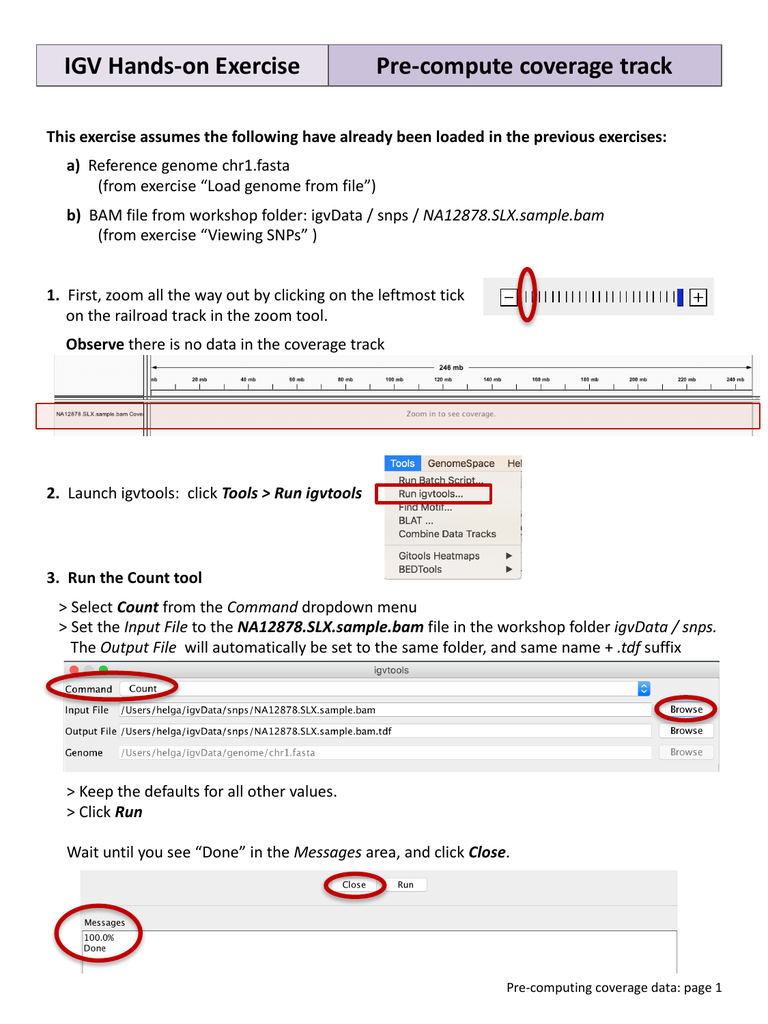

Zoom all the way out → *“Zoom in to see coverage”*

IGV computes BAM coverage **on the fly** — too slow for a whole chromosome.

**Fix:** precompute it once with igvtools

1. Tools > Run igvtools…
2. Command: **Count**
3. Input: `NA12878.SLX.sample.bam` → **Run**

## Attach the TDF file

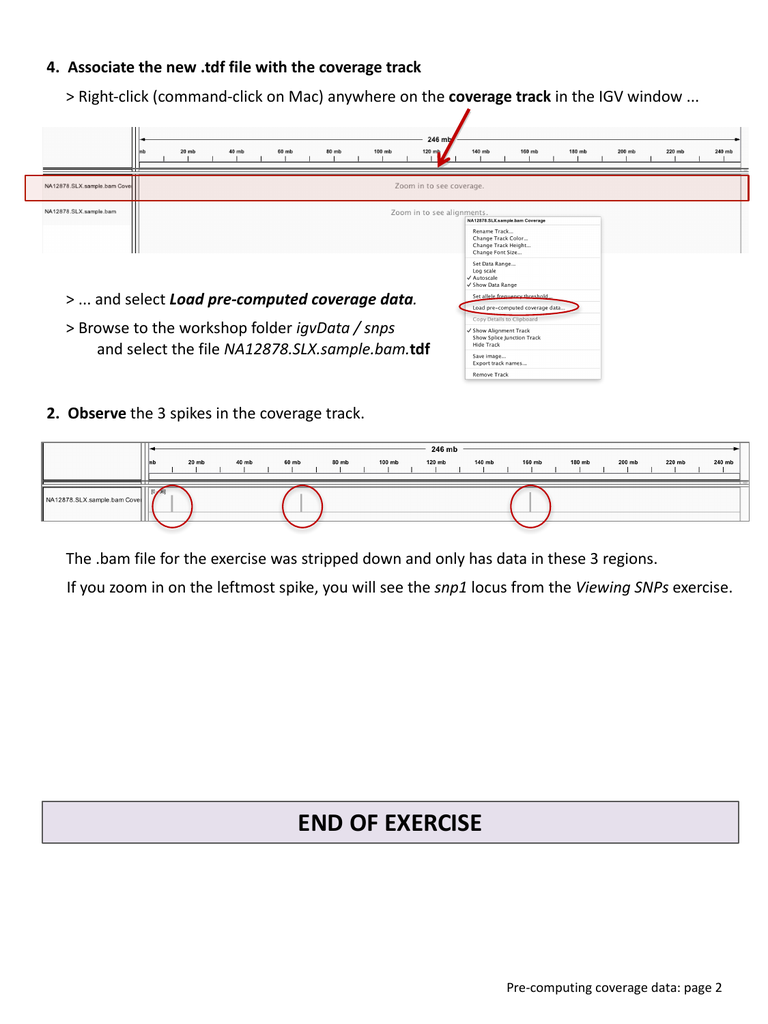

Right-click the coverage track → **Load pre-computed coverage data…**

Pick `NA12878.SLX.sample.bam.tdf`

Three coverage spikes appear across chr1 — the workshop BAM only contains reads in these regions.

## Your turn: zoom back in

Zoom in on the **leftmost** spike until you reach base-pair resolution. Where do you land?

Back at `snp1`! Same reads — the coverage is just computed differently depending on zoom level.

# RNA-seq & Splicing

Episode 06

How do I compare splicing between tissues?

## Why RNA-seq reads look “split”

[figure not shown]

Reads come from spliced mRNA, but the genome still has introns → a read spanning two exons aligns as a **gapped** alignment

## Set up and load

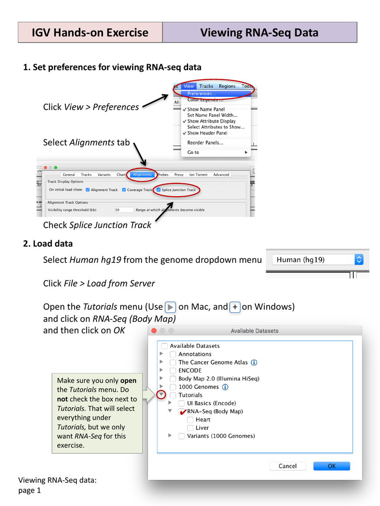

1. View > Preferences > Alignments tick **Splice Junction Track**
2. Genome **Human hg19**
3. File > Load from Server… Tutorials → **RNA-Seq (Body Map)**

Two tissues: **heart** and **liver**

## Coverage and junctions

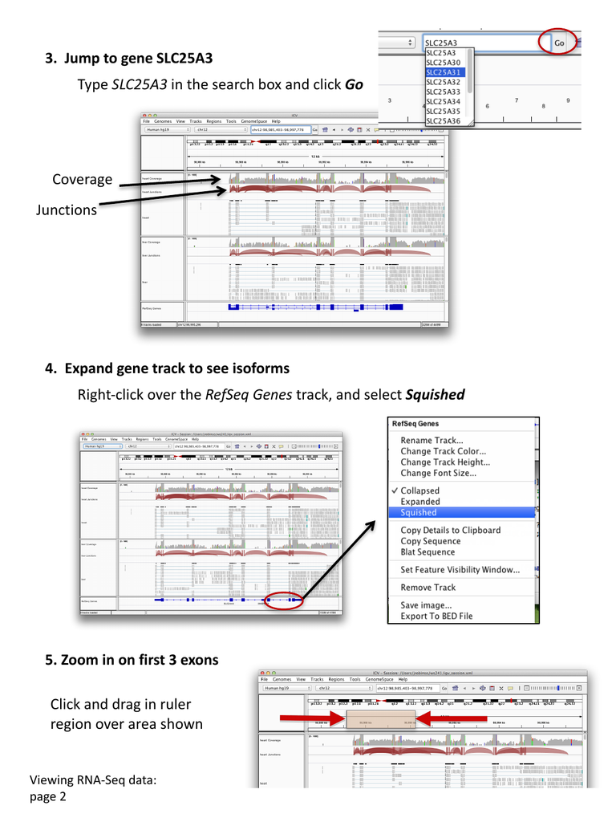

Search `SLC25A3`

For each tissue:

- **Coverage** — reads per position
- **Junctions** — arcs joining spliced exons

Right-click RefSeq Genes → **Squished** to see the isoforms

## Your turn: spot the difference

Zoom in on the **first three exons**. Is there an exon with coverage in one tissue but not the other?

Yes — one tissue has a small coverage bump (an extra exon) that is missing or much lower in the other. That’s **tissue-specific alternative splicing**.

## Sashimi plots

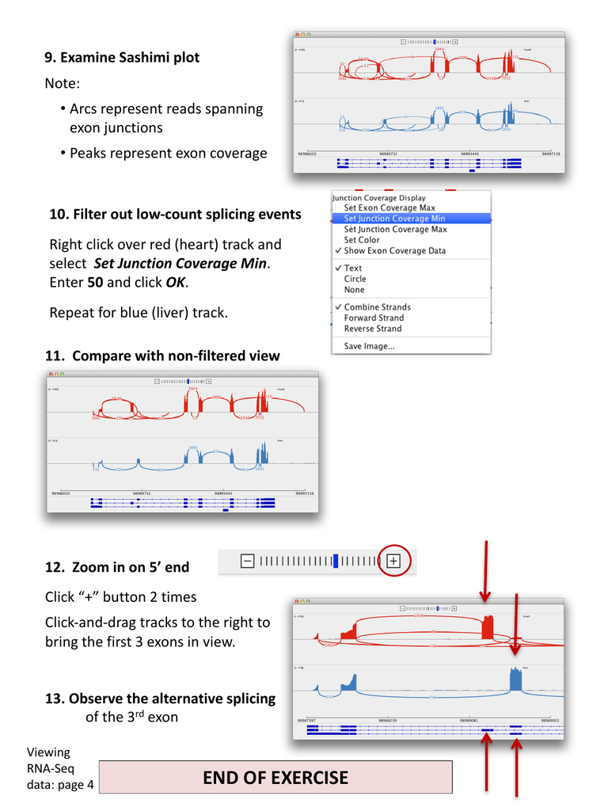

Right-click junctions → **Sashimi Plot** → tick heart & liver

- **Arcs** = reads across a junction (number = read count)
- **Peaks** = exon coverage

Right-click → **Set Junction Coverage Min** → `50` to hide low-count junctions

## Your turn: exon 3

In the Sashimi plot, zoom to the 5′ end. Compare the heart and liver arcs around **exon 3**.

In one tissue an arc **skips** exon 3 (exon 2 → exon 4); in the other, arcs go into and out of exon 3. Read-level evidence that exon 3 is alternatively spliced.

## Watch: RNA-seq in IGV

[video not shown]

Basics: junction track, downsampling

[video not shown]

Advanced: alternative splicing, Sashimi plots

# Variants & Genotypes

Episode 07

How can I compare variants across populations?

## The dataset

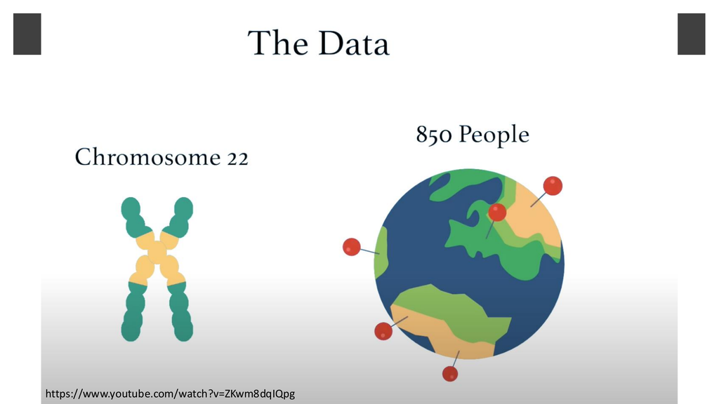

1000 Genomes: chromosome 22, ~850 people from populations around the world

## The APOL1 story

[figure not shown]

Protects against African sleeping sickness · linked to kidney disease (Genovese *et al.*, *Science* 2010)

## Load the session

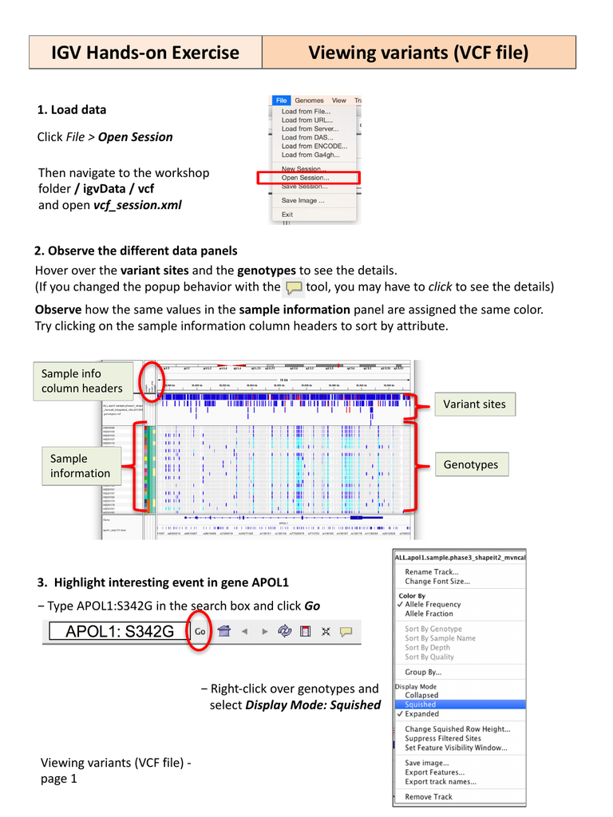

File > Open Session… `igvData/vcf/vcf_session.xml`

Two panels:

- **Variant sites** — one row
- **Genotypes** — one row per sample

A **sample info** colour bar shows metadata such as population.

## Reading the colours

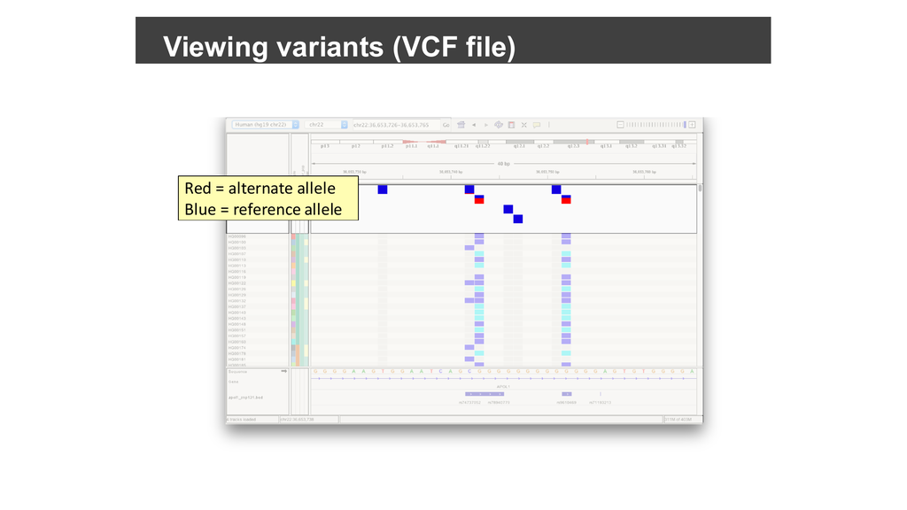

**Variant sites**

reference allele alternate allele

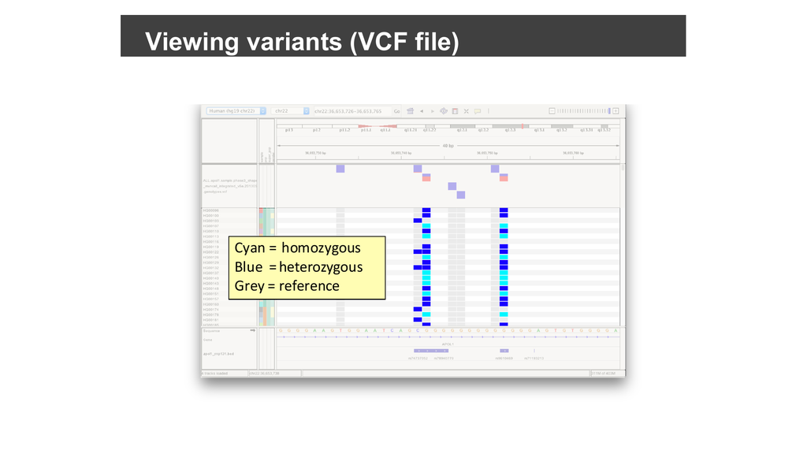

**Genotypes**

homozygous alt heterozygous homozygous ref

## Group by population

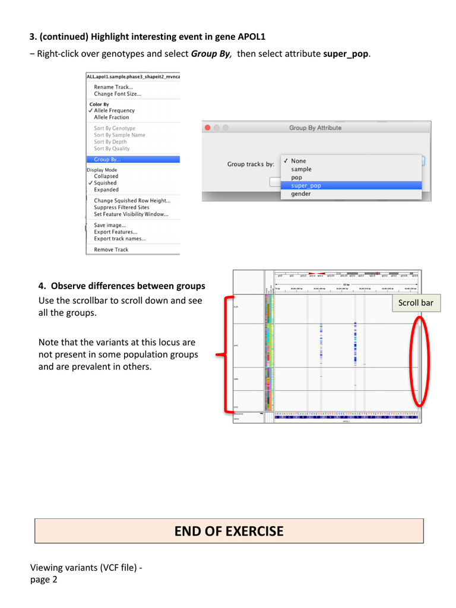

1. Search `APOL1:S342G` (gene:protein change!)
2. Right-click genotypes → **Squished**
3. Right-click → **Group By…** → `super_pop`
4. Scroll through the groups

Sample metadata comes from a separate tab-delimited file whose first column matches the VCF sample names.

## Your turn: population frequencies

At `APOL1:S342G`, scroll through the population groups.

Is the variant equally common everywhere?

No — it’s absent or rare in most groups and common in **African** populations, matching the selective history of *APOL1*. Grouping makes this visible without computing any frequencies.

## Watch: VCF basics

[video not shown]

# Structural Variants

Episode 08

How can paired-end reads reveal deletions, fusions and inversions?

## Insert size & orientation

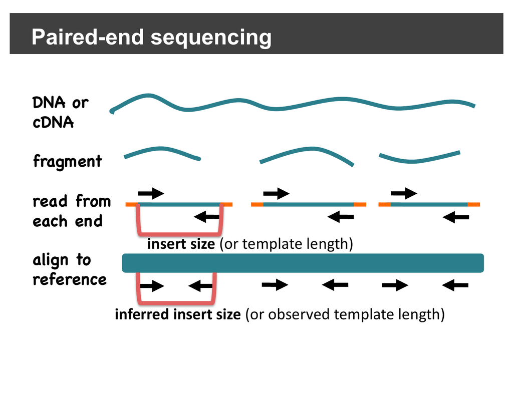

Compare the **inferred** insert size and pair orientation with what we expect — the same evidence SV callers use

## Deletions

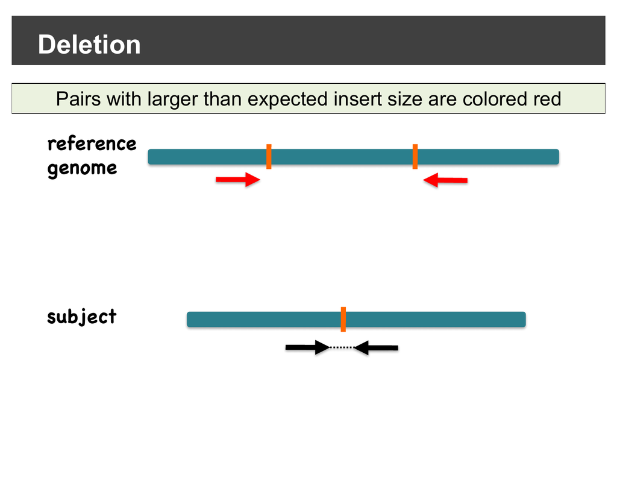

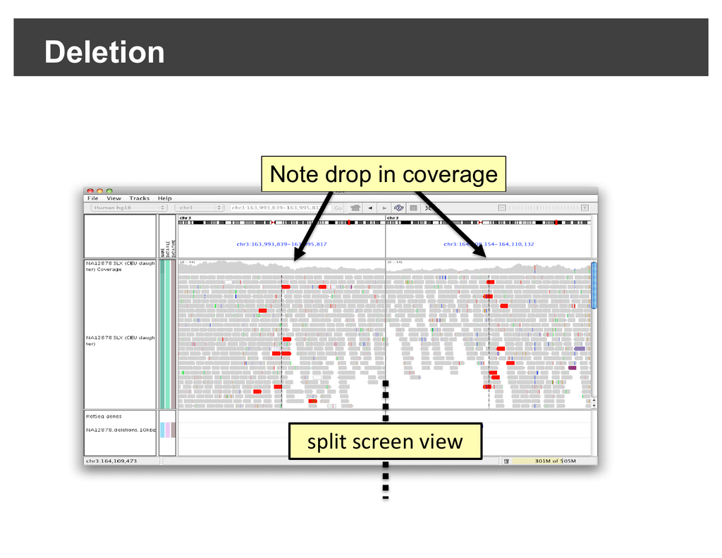

Mates land **further apart** than expected → coloured red · coverage drops between the breakpoints